# Sta112FS 4. Tidy data & Intro to data visualization

Dr. Çetinkaya-Rundel

September 3, 2015

# From last time…

## A note on piping and layering

- The `%>%` operator in `dplyr` functions is called the pipe operator. This means you “pipe” the output of the previous line of code as the first input of the next line of code.
- The `+` operator in `ggplot2` functions is used for “layering”. This means you create the plot in layers, separated by `+`.

# Today’s agenda

## Today’s agenda

- Highlights from the “Tidy data” paper
- Visualizing data with `ggplot2`
  - **Goal:** Learn syntax and various visualizations for different data types

# Tidy data

## Tidy data

1. Each variable forms a column.
2. Each observation forms a row.
3. Each type of observational unit forms a table.

Which of the following is a data set and which is a summary table?

```
## Source: local data frame [5 x 2]
##
##   continent mean_lifeexp
## 1    Africa     54.80604
## 2  Americas     73.60812
## 3      Asia     70.72848
## 4    Europe     77.64860
## 5   Oceania     80.71950
```

```
## Source: local data frame [142 x 3]
##
##                     country continent lifeExp
## 1                   Algeria    Africa  72.301
## 2                    Angola    Africa  42.731
## 3                     Benin    Africa  56.728
## 4                  Botswana    Africa  50.728
## 5              Burkina Faso    Africa  52.295
## 6                   Burundi    Africa  49.580
## 7                  Cameroon    Africa  50.430
## 8  Central African Republic    Africa  44.741
## 9                      Chad    Africa  50.651
## 10                  Comoros    Africa  65.152
## ..                      ...       ...     ...
```

# Data visualization

## `ggplot2`

- To use `ggplot2` functions, first load the package

```r
library(ggplot2)
```

- In `ggplot2` the structure of the code for plots can often be summarized as

```r
ggplot +
  geom_xxx
```

or, more precisely

```r
ggplot(data = [dataset], aes(x = [x-variable], [y-variable])) +
   geom_xxx() +
   other options
```

- Geoms, short for geometric objects, describe the type of plot you will produce

## Context: Fuel economy

**data:** `mpg` - fuel economy data from 1999 and 2008 for 38 popular models of cars

- Run the following **in the Console**:

```r
# see the help file
?mpg
```

```r
# view data
View(mpg)
```

How many rows and columns does this dataset have? What does each row represent? What does each column represent?

Make a prediction: What relationship do you expect to see between engine size (displ) and mileage (hwy)?

# Scatterplots

## Displacement vs. highway mpg (`geom_point()`)

How would you describe this relationship? What other variables would help us understand data points that don’t follow the overall trend?

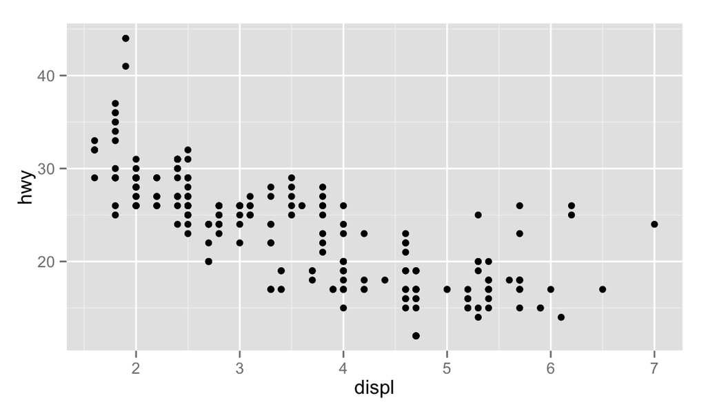

```r
ggplot(data = mpg, aes(x = displ, y = hwy)) +
  geom_point()
```

## Additional variables

Can display additional variables with

- aesthetics (like shape, colour, size), or
- faceting (small multiples displaying different subsets)

# Aesthetics

## Aesthetics options

Visual characteristics of plotting characters that can be **mapped to data** are

- `color`
- `size`
- `shape`
- `alpha` (transparency)

## Displacement vs. highway mpg + class

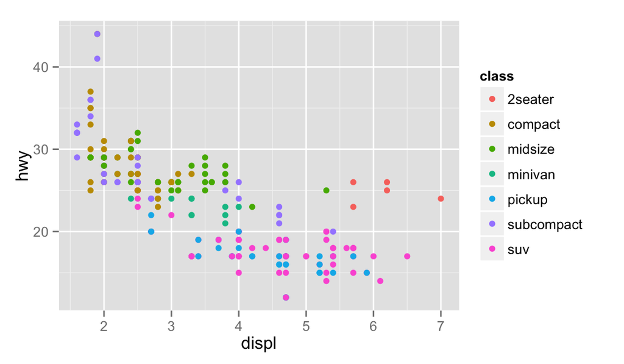

```r
ggplot(data = mpg, aes(x = displ, y = hwy, color = class)) +
  geom_point()
```

## Aesthetics summary

| aesthetics | discrete | continuous |
| --- | --- | --- |
| color | rainbow of colors | gradient |
| size | discrete steps | linear mapping between radius and value |
| shape | different shape for each | shouldn’t (and doesn’t) work |

# Faceting

## Faceting options

- Smaller plots that display different subsets of the data
- Useful for exploring conditional relationships and large data

## Displacement vs. highway mpg by cylinders

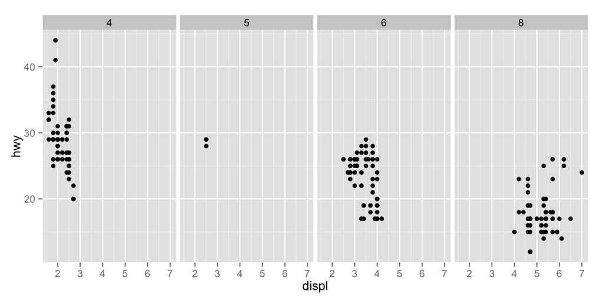

```r
ggplot(data = mpg, aes(x = displ, y = hwy)) +
  facet_grid(. ~ cyl) +
  geom_point()
```

## Dive further…

In the next few slides describe what each plot displays. Think about how the code relates to the output.

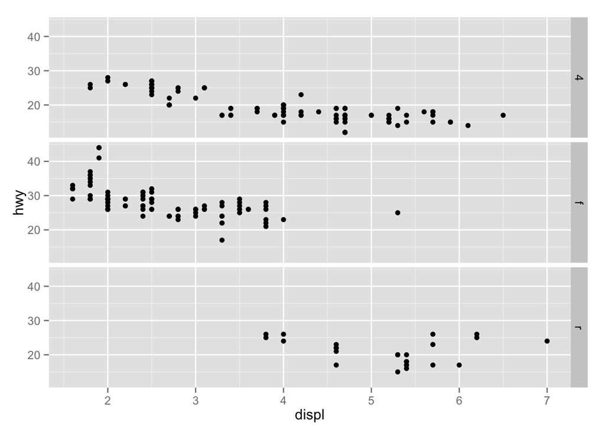

```r
ggplot(data = mpg, aes(x = displ, y = hwy)) +
  facet_grid(drv ~ .) +
  geom_point()
```

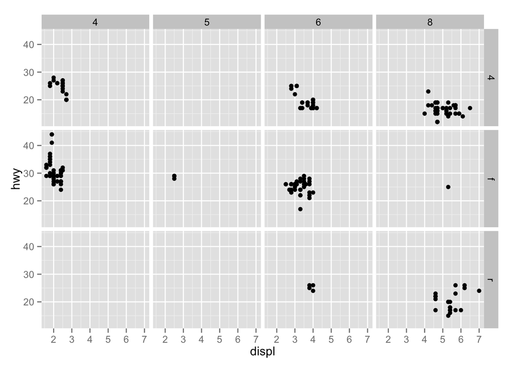

```r
ggplot(data = mpg, aes(x = displ, y = hwy)) +
  facet_grid(drv ~ cyl) +
  geom_point()
```

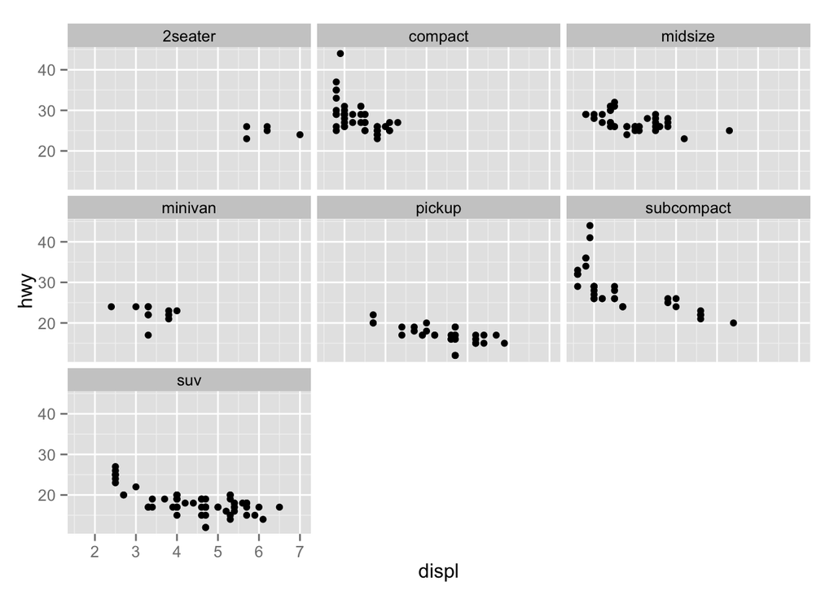

```r
ggplot(data = mpg, aes(x = displ, y = hwy)) +
  facet_wrap(~ class) +
  geom_point()
```

## Facet summary

- `facet_grid()`: 2d grid, rows ~ cols, . for no split
- `facet_wrap()`: 1d ribbon wrapped into 2d

# Other geoms

## Displacement vs. highway mpg, take 2

How are these plots similar? How are they different?

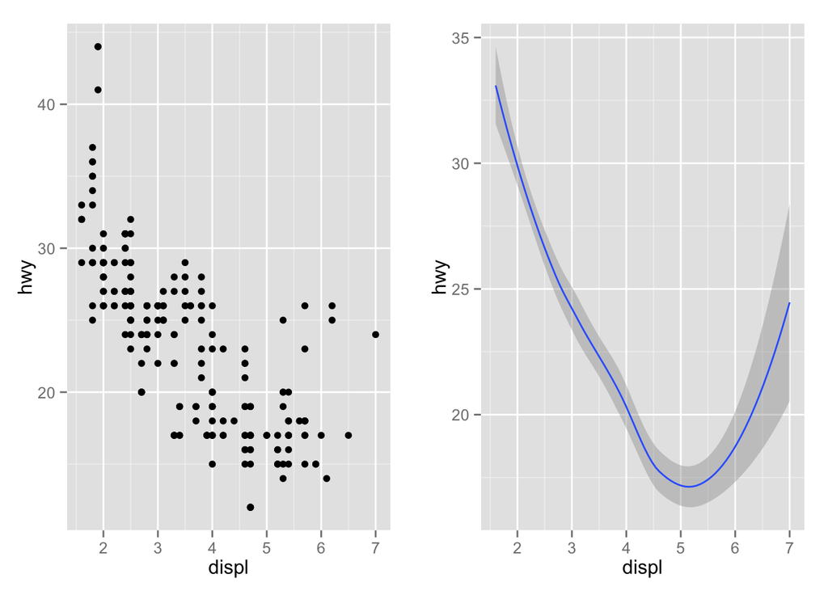

## `geom_smooth`

To plot a smooth curve, use `geom_smooth()`

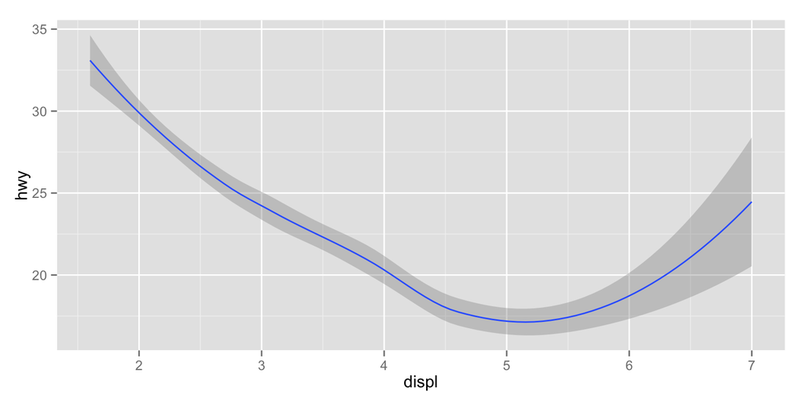

```r
ggplot(data = mpg, aes(x = displ, y = hwy)) +
  geom_smooth()
```

# Exploratory data analysis (EDA)

## Number of variables involved

- Univariate data analysis - distribution of single variable
- Bivariate data analysis - relationship between two variables
- Multivariate data analysis - relationship between many variables at once, usually focusing on the relationship between two while conditioning for others

## Types of variables

- **Numerical variables** can be classified as **continuous** or **discrete** based on whether or not the variable can take on an infinite number of values or only non-negative whole numbers, respectively.
- If the variable is **categorical**, we can determine if it is **ordinal** based on whether or not the levels have a natural ordering.

## Describing shapes of numerical distributions

- shape:
  - skewness: right-skewed, left-skewed, symmetric (skew is to the side of the longer tail)
  - modality: unimodal, bimodal, multimodal, uniform
- center: mean (`mean`), median (`median`), mode (not always useful)
- spead: range (`range`), standard deviation (`sd`), inter-quartile range (`IQR`)
- unusal observations

[Put these, and more, to use in HW 1]

# Homework